# Cellular Automata

**Tip**

`fireplot` and `fireplot!` work with both `LevelSetGrid` and `CAGrid`. Load a Makie backend (e.g. `using CairoMakie`) to enable them.

The `CellularAutomata` module implements a **deterministic, grid-based** fire spread model using a travel-time approach. Each cell occupies one of four discrete states and transitions are governed by directional spread rates from a `RothermelModel`.

## How It Works

### Cell States

Each cell is in exactly one of four states:

| State | Value | Meaning |
| --- | --- | --- |
| `UNBURNED` | 0 | Fuel available, not yet ignited |
| `BURNING` | 1 | Actively on fire |
| `BURNED` | 2 | Fuel consumed, fire passed |
| `UNBURNABLE` | 3 | Cannot ignite (water, road, fuel break) |

```julia
(UNBURNED, BURNING, BURNED, UNBURNABLE)
```

```
(UNBURNED, BURNING, BURNED, UNBURNABLE)
```

### State Transitions

At each time step, three phases occur:

1. **Spread**: For each `BURNING` cell, compute directional spread rate `R(θ)` to each `UNBURNED` neighbor. The travel time is `distance / R(θ)`, and the neighbor’s arrival time is updated.
2. **Ignition**: Cells whose minimum arrival time has been reached transition to `BURNING`.
3. **Burnout**: `BURNING` cells whose elapsed time exceeds the `residence_time` transition to `BURNED`.

```
UNBURNED ──(arrival time reached)──▶ BURNING ──(burnout)──▶ BURNED
                                        ▲
UNBURNABLE: never transitions ──────────╳
```

## Neighborhoods

Two neighborhood types control which cells can spread fire:

| Type | Neighbors | Description |
| --- | --- | --- |
| `Moore()` | 8 | Cardinal + diagonal (default) |
| `VonNeumann()` | 4 | Cardinal only |

## `CAGrid`

The simulation grid stores per-cell states and ignition times:

```julia
grid = CAGrid(100, 100, dx=30.0)
```

```
CAGrid{Float64} 100×100 (t=0.0, burning=0, burned=0/10000)
```

```julia
grid_vn = CAGrid(100, 100, dx=30.0, neighborhood=VonNeumann())
```

```
CAGrid{Float64} 100×100 (t=0.0, burning=0, burned=0/10000, neighborhood=VonNeumann)
```

### Coordinates

```julia
xs = xcoords(grid)
println("x: $(first(xs)) to $(last(xs)) m  ($(length(xs)) cells)")

ys = ycoords(grid)
println("y: $(first(ys)) to $(last(ys)) m  ($(length(ys)) cells)")
```

```
x: 15.0 to 2985.0 m  (100 cells)
y: 15.0 to 2985.0 m  (100 cells)
```

## Ignition

```julia
ignite!(grid, 1500.0, 1500.0, 100.0)
grid
```

```
CAGrid{Float64} 100×100 (t=0.0, burning=32, burned=0/10000)
```

## Queries

```julia
burn_area(grid)  # m²
```

```
28800.0
```

```julia
count(burning(grid))  # number of actively burning cells
```

```
32
```

## Simulation with RothermelModel

The same `RothermelModel` used with `LevelSetGrid` drives the CA simulation. The CA uses `directional_speed` to compute direction-dependent spread rates to each neighbor, supporting both `CosineBlending` and `EllipticalBlending`.

```julia
M = FuelClasses(d1=0.06, d10=0.07, d100=0.08, herb=0.0, wood=0.0)
model = RothermelModel(SHORT_GRASS, UniformWind(speed=8.0), UniformMoisture(M), FlatTerrain())

g = CAGrid(100, 100, dx=30.0)
ignite!(g, 1500.0, 1500.0, 100.0)
simulate!(g, model, steps=50)
g
```

```
CAGrid{Float64} 100×100 (t=24.100944217000432, burning=572, burned=0/10000)
```

### Plotting Cell States

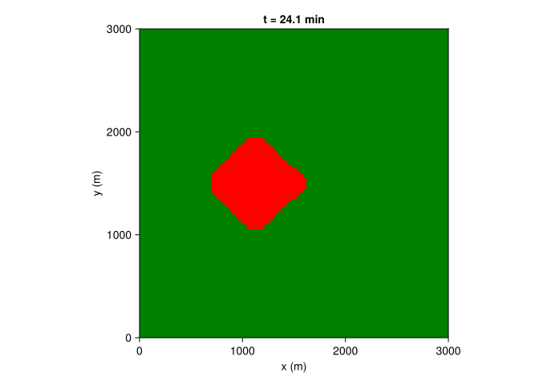

```julia
fireplot(g)
```

## Full Example

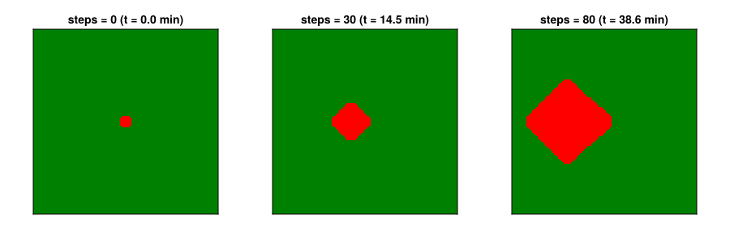

```julia
M = FuelClasses(d1=0.06, d10=0.07, d100=0.08, herb=0.0, wood=0.0)

fig = Figure(size=(900, 280))
steps_list = [0, 30, 80]
for (col, nsteps) in enumerate(steps_list)
    g = CAGrid(100, 100, dx=30.0)
    ignite!(g, 1500.0, 1500.0, 100.0)
    m = RothermelModel(SHORT_GRASS, UniformWind(speed=8.0), UniformMoisture(M), FlatTerrain())
    nsteps > 0 && simulate!(g, m, steps=nsteps)
    ax = Axis(fig[1, col], title="steps = $nsteps (t = $(round(g.t, digits=1)) min)", aspect=DataAspect())
    fireplot!(ax, g)
    hidedecorations!(ax)
end
fig
```

### Animation

```julia
using Wildfires.SpreadModels: Trace

M = FuelClasses(d1=0.06, d10=0.07, d100=0.08, herb=0.0, wood=0.0)
g = CAGrid(100, 100, dx=30.0)
ignite!(g, 1500.0, 1500.0, 100.0)
model = RothermelModel(SHORT_GRASS, UniformWind(speed=8.0), UniformMoisture(M), FlatTerrain())

trace = Trace(g, 2)
simulate!(g, model, steps=80, trace=trace)
firegif(joinpath(@__DIR__, "ca_spread.gif"), trace, g)
```

```
"/home/runner/work/Wildfires.jl/Wildfires.jl/docs/ca_spread.gif"
```

[figure not shown]

## Blending Modes

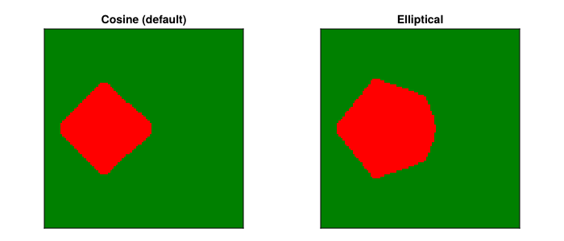

```julia
M = FuelClasses(d1=0.06, d10=0.07, d100=0.08, herb=0.0, wood=0.0)

fig = Figure(size=(700, 300))
for (col, (label, blend)) in enumerate([
    ("Cosine (default)", CosineBlending()),
    ("Elliptical", EllipticalBlending()),
])
    g = CAGrid(100, 100, dx=30.0)
    ignite!(g, 1500.0, 1500.0, 100.0)
    m = RothermelModel(SHORT_GRASS, UniformWind(speed=8.0), UniformMoisture(M), FlatTerrain(), blend)
    simulate!(g, m, steps=80)
    ax = Axis(fig[1, col], title=label, aspect=DataAspect())
    fireplot!(ax, g)
    hidedecorations!(ax)
end
fig
```

## Fuel Breaks

Mark cells as `UNBURNABLE` to create barriers that block fire spread:

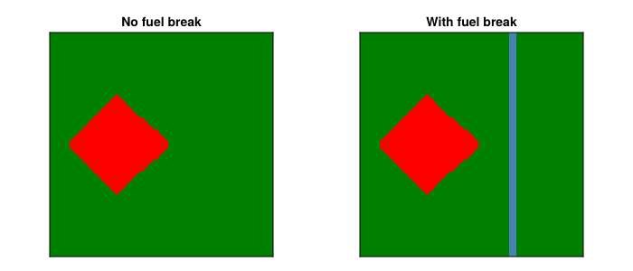

```julia
M = FuelClasses(d1=0.06, d10=0.07, d100=0.08, herb=0.0, wood=0.0)
model = RothermelModel(SHORT_GRASS, UniformWind(speed=8.0), UniformMoisture(M), FlatTerrain())

fig = Figure(size=(700, 300))

# Without fuel break
g1 = CAGrid(100, 100, dx=30.0)
ignite!(g1, 1500.0, 1500.0, 60.0)
simulate!(g1, model, steps=80)
ax1 = Axis(fig[1, 1], title="No fuel break", aspect=DataAspect())
fireplot!(ax1, g1)
hidedecorations!(ax1)

# With fuel break (vertical strip)
g2 = CAGrid(100, 100, dx=30.0)
ignite!(g2, 1500.0, 1500.0, 60.0)
xs = collect(xcoords(g2))
for j in eachindex(xs)
    if 2000.0 <= xs[j] <= 2100.0
        for i in 1:size(g2, 1)
            set_unburnable!(g2, xs[j], ycoords(g2)[i], 1.0)
        end
    end
end
simulate!(g2, model, steps=80)
ax2 = Axis(fig[1, 2], title="With fuel break", aspect=DataAspect())
fireplot!(ax2, g2)
hidedecorations!(ax2)
fig
```

## Burnout

`BURNING` cells transition to `BURNED` after `residence_time` minutes and stop spreading fire. Shorter residence times mean faster burnout:

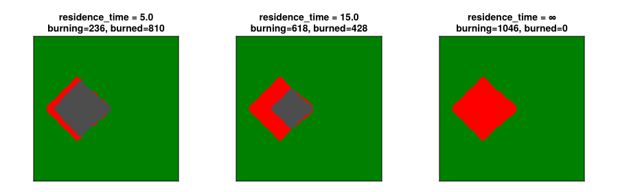

```julia
M = FuelClasses(d1=0.06, d10=0.07, d100=0.08, herb=0.0, wood=0.0)

fig = Figure(size=(900, 280))
for (col, rt) in enumerate([5.0, 15.0, Inf])
    g = CAGrid(100, 100, dx=30.0)
    ignite!(g, 1500.0, 1500.0, 60.0)
    m = RothermelModel(SHORT_GRASS, UniformWind(speed=8.0), UniformMoisture(M), FlatTerrain())
    simulate!(g, m, steps=80, residence_time=rt)
    nb = count(burning(g))
    nd = count(burned(g))
    label = rt == Inf ? "∞" : string(rt)
    ax = Axis(fig[1, col],
        title="residence_time = $label\nburning=$nb, burned=$nd",
        aspect=DataAspect())
    fireplot!(ax, g)
    hidedecorations!(ax)
end
fig
```

### Animation

```julia
M = FuelClasses(d1=0.06, d10=0.07, d100=0.08, herb=0.0, wood=0.0)
g = CAGrid(100, 100, dx=30.0)
ignite!(g, 1500.0, 1500.0, 60.0)
model = RothermelModel(SHORT_GRASS, UniformWind(speed=8.0), UniformMoisture(M), FlatTerrain())

trace = Trace(g, 2)
simulate!(g, model, steps=80, residence_time=5.0, trace=trace)
firegif(joinpath(@__DIR__, "ca_burnout.gif"), trace, g)
```

```
"/home/runner/work/Wildfires.jl/Wildfires.jl/docs/ca_burnout.gif"
```

[figure not shown]

## References

- Carrasco, J. et al. (2021). *Cell2Fire: A cell-based forest fire growth model.* Frontiers in Forests and Global Change, 4, 692706.